# MetabolomicsPipeline Report

# Introduction

This report provides a summary of the metabolomics data analysis using MetabolomicsPipeline dashboard. In this report, we include an exploratory data analysis, subpathway analsysis, pairwise analysis and subpathway plots. The experiment includes a total of 86 samples and 1102 metabolites. If using the MetabolomicsPipeline dashboard for preprocessing, the peak data is median standardized, min value imputed, and log transformed for the downstream analysis.

```r
# Create table1
form <- as.formula(
    if(params$stratVarDist == "None"){
      paste0("~ ", paste(params$includedVarsDist, collapse = " + "))
    } else {
      paste0("~ ", paste(params$includedVarsDist, collapse = " + "), " | ",
             params$stratVarDist)
    }
    )


table1(form, data = colData(params$dat))
```

|  | Female (N=44) | Male (N=42) | Overall (N=86) |
| --- | --- | --- | --- |
| GROUP_NAME |  |  |  |
| Control | 14 (31.8%) | 14 (33.3%) | 28 (32.6%) |
| treat1 | 15 (34.1%) | 14 (33.3%) | 29 (33.7%) |
| treat2 | 15 (34.1%) | 14 (33.3%) | 29 (33.7%) |
| TIME1 |  |  |  |
| End | 14 (31.8%) | 15 (35.7%) | 29 (33.7%) |
| Onset | 15 (34.1%) | 14 (33.3%) | 29 (33.7%) |
| PreSymp | 15 (34.1%) | 13 (31.0%) | 28 (32.6%) |

# Exploratory Data Analysis

## PCA

In general, Principal component analysis (PCA) reduces the number of variables in a dataset while preserving as much information from the data as possible. At a high level, PCA is constructed such that the first principal component (PC) accounts for the largest amount of variance within the data. The second PC accounts for the largest remaining variance, and so on. Additionally, each of the PCs produced by PCA is uncorrelated with the other principal components. PCA can allow us to visualize sources of variation in the data.

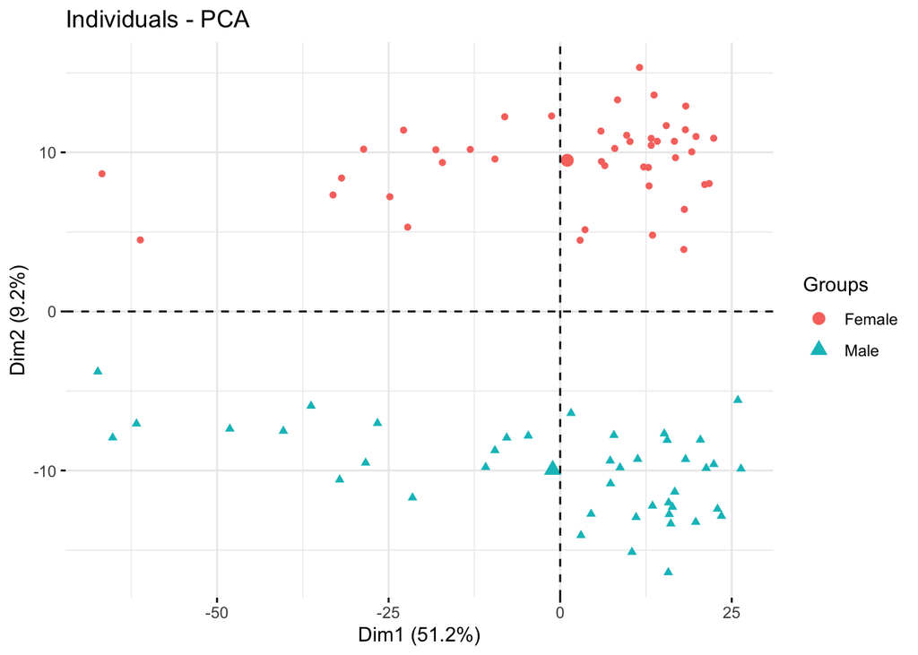

```r
# PCA plot
# Define PCA label from metadata
meta_var <- params$pcaColor

# Run PCA
pca <- metabolite_pca(params$dat,
    meta_var = meta_var
)


# Show PCA
pca
```

## Heatmap

For our heatmap, the x-axis will be the samples, and the y-axis will be the metabolites. The values determining the colors will be the normalized peak values for each metabolite in each observation. We can group the observations by the experimental conditions. Grouping the experimental conditions in a heatmap is another way of visualizing sources of variation.

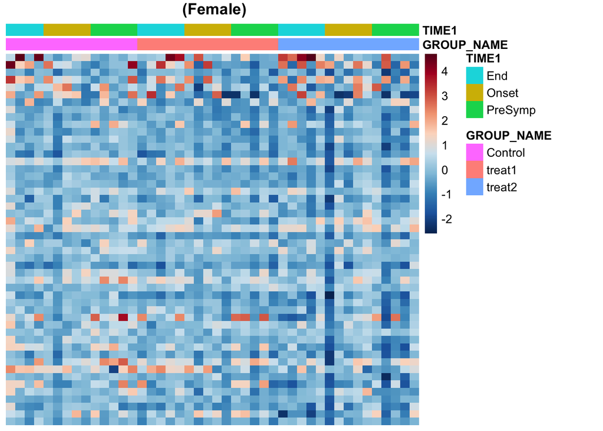

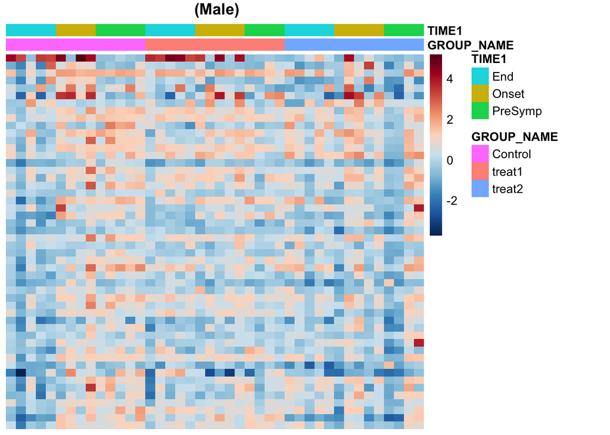

```r
metabolite_heatmap(params$dat,
                        top_mets = params$metsNumber,
                        group_vars = params$groupVars,
                        strat_var = params$stratVar,
                        caption = "",
                        Assay = "normalized",
                        !!!syms(params$groupVars))
```

# Subpathway Analysis

Each metabolite is nested within a subpathway, which in turn is nested within a superpathway. To test for differences in peak intensities between treatment groups at the metabolite level, we use an Analysis of Variance (ANOVA) model. However, because multiple metabolites belong to the same subpathway, it is challenging to assess treatment effects at the subpathway level directly. To address this, we apply Fisher’s combined probability test, which aggregates p-values from independent tests to evaluate whether there is an overall effect. This approach allows us to assess subpathway-level effects based on the p-values obtained from metabolite-level models.

### Combined Fished Analysis

We will test at the subpathway level by combining the p-values for each metabolite within the subpathway for each model. We use a combination function given by $\tilde{X}$ which combines the pvalues, resulting in a chi-squared test statistic.

$$\tilde{X} = -2\sum_{i=1}^k ln(p_i)$$

where $k$ is the number of metabolites in the subpathway. We can get a p-value from $P(X \geq\tilde{X})$, knowing that $\tilde{X}\sim \chi^2_{2k}$. You will notice that smaller p-values will lead to a larger $\tilde{X}$.

##### Assumptions

Since we are first testing each metabolite utilizing ANOVA, we make the following assumptions for each metabolite,

- *Independence:* Each observation is independent of all other observations. Therefore, if you have collected multiple samples from the same subject then this assumption may be violated.
- *Normality:* The normalized metabolite intensities follow a normal distribution within each of the treatment groups.
- *Homoscedasticity:* Equal variance between treatment groups.

In addition to the assumptions in the ANOVA models at the metabolite level, the Fisher’s Combined probability places an independence assumption between the metabolites within the subpathway.

For more about the Combined Fisher Probability and other methods that can address this problem, see:

Loughin, Thomas M. “A systematic comparison of methods for combining p-values from independent tests.” Computational statistics & data analysis 47.3 (2004): 467-485.

#### Models

To test our hypothesis at the subpathway level, we first have to form our hypothesis at the metabolite level. For each metabolite, we test three models.

1.) Interaction: $nornalized Peak = Treatment Group + Block + Treatment*Block$

2.) Parallel: $normalized Peak = Treatment Group + Block$

3.) Single: $normalized Peak = Treatment$

For the interaction model, we are focusing only on the interaction term “Treatment*Block” to test if there is a significant interaction between our treatment and the block variable. The parallel model is testing if the block variable is explaining a significant amount of the metabolite variance with treatment included, and the treatment model is testing if the treatment explains a significant proportion of the variance for each metabolite.

```r
subpath_by_model(params$subpath_analysis)
```

Sigificant Pathways by Model

| Model Type | Female | Male |
| --- | --- | --- |
| Interaction | 6 | 84 |
| Parallel | 21 | 12 |
| Single | 19 | 2 |
| None | 64 | 12 |

```r
# Create subpath within superpath table
subpath_within_superpath(params$subpath_analysis)
```

Proportion of significant subpathways within superpathways

| Super Pathway | Percent Significant (Female) | \|Percent Significant (Male |
| --- | --- | --- |
| Xenobiotics | 5 / 5 (100%) | 5 / 5 (100%) |
| Amino Acid | 13 / 16 (81.25%) | 16 / 16 (100%) |
| Peptide | 3 / 5 (60%) | 3 / 5 (60%) |
| Nucleotide | 3 / 8 (37.5%) | 8 / 8 (100%) |
| Lipid | 17 / 53 (32.08%) | 46 / 53 (86.79%) |
| Carbohydrate | 2 / 8 (25%) | 7 / 8 (87.5%) |
| Cofactors and Vitamins | 2 / 11 (18.18%) | 9 / 11 (81.82%) |
| Energy | 0 / 2 (0%) | 2 / 2 (100%) |
| Partially Characterized Molecules | 0 / 1 (0%) | 1 / 1 (100%) |

```r
# Show metabolites within subpathway
tables <- met_within_sub(params$subpath_analysis, subpathway = params$subpath_selection)

# Combine and return as HTML
HTML(paste(tables, collapse = "<br><br>"))
```

Metabolites within Partially Characterized Molecules (Female)

| Metabolite Name | Interaction_pval P-Value | Parallel_pval P-Value | Single_pval P-Value |
| --- | --- | --- | --- |
| glutamine_degradant* | 0.488 | 0.630 | 0.285 |
| glucuronide of C14H22O4 (1)* | 0.431 | 0.970 | 0.332 |
| glucuronide of C10H18O2 (11)* | 0.927 | 0.288 | 0.671 |
| glucuronide of C10H18O2 (12)* | 0.996 | 0.436 | 0.390 |
| glycine conjugate of C10H14O2 (1)* | 0.999 | 0.061 | 0.781 |
| pentose acid* | 0.154 | 0.772 | 0.104 |
| branched-chain, straight-chain, or cyclopropyl 10:1 fatty acid (1)* | 0.891 | 0.405 | 0.909 |
| branched-chain, straight-chain, or cyclopropyl 10:1 fatty acid (2)* | 0.962 | 0.708 | 0.999 |
| glycine conjugate of C6H10O2 (2)* | 0.659 | 0.979 | 0.090 |
| glycine conjugate of C6H10O2 (3)* | 0.981 | 0.509 | 0.706 |
| branched-chain, straight-chain, or cyclopropyl 12:1 fatty acid* | 0.899 | 0.274 | 0.717 |
| bilirubin degradation product, C17H18N2O4 (1)** | 0.189 | 0.238 | 0.193 |
| bilirubin degradation product, C17H18N2O4 (2)** | 0.410 | 0.143 | 0.243 |
| bilirubin degradation product, C17H18N2O4 (3)** | 0.591 | 0.140 | 0.261 |
| bilirubin degradation product, C17H20N2O5 (1)** | 0.821 | 0.098 | 0.771 |
| bilirubin degradation product, C17H20N2O5 (2)** | 0.881 | 0.155 | 0.675 |

Metabolites within Partially Characterized Molecules (Male)

| Metabolite Name | Interaction_pval P-Value | Parallel_pval P-Value | Single_pval P-Value |
| --- | --- | --- | --- |
| glutamine_degradant* | 0.100 | 0.011 | 0.844 |
| glucuronide of C14H22O4 (1)* | 0.505 | 0.388 | 0.377 |
| glucuronide of C10H18O2 (11)* | 0.413 | 0.546 | 0.533 |
| glucuronide of C10H18O2 (12)* | 0.013 | 0.739 | 0.837 |
| glycine conjugate of C10H14O2 (1)* | 0.028 | 0.691 | 0.403 |
| pentose acid* | 0.058 | 0.039 | 0.482 |
| branched-chain, straight-chain, or cyclopropyl 10:1 fatty acid (1)* | 0.258 | 0.805 | 0.351 |
| branched-chain, straight-chain, or cyclopropyl 10:1 fatty acid (2)* | 0.045 | 0.516 | 0.161 |
| glycine conjugate of C6H10O2 (2)* | 0.322 | 0.360 | 0.917 |
| glycine conjugate of C6H10O2 (3)* | 0.160 | 0.469 | 0.748 |
| branched-chain, straight-chain, or cyclopropyl 12:1 fatty acid* | 0.015 | 0.502 | 0.001 |
| bilirubin degradation product, C17H18N2O4 (1)** | 0.225 | 0.003 | 0.778 |
| bilirubin degradation product, C17H18N2O4 (2)** | 0.070 | 0.037 | 0.846 |
| bilirubin degradation product, C17H18N2O4 (3)** | 0.031 | 0.135 | 0.647 |
| bilirubin degradation product, C17H20N2O5 (1)** | 0.294 | 0.278 | 0.510 |
| bilirubin degradation product, C17H20N2O5 (2)** | 0.229 | 0.626 | 0.333 |

# Pairwise Analysis

### Log Fold-Change Heatmap

We will produce a heatmap of the log fold changes for the metabolites with a significant overall p-value (which tested if the treatment group means were equal under the null hypothesis). The heatmap colors will only show if the log fold-change is greater than log(2) or less than log(.5). Therefore, this heatmap will only focus on comparisons with a fold change of two or greater.

### P-Value Heatmap

Similar to the pairwise estimate heatmap, we will produce a heatmap where the heatmap will only include metabolites with a significant overall p-value, and the values in the heat map will only be colored if the pairwise comparison is significant.

```r
# Read in example pairwise data
pairwise_analysis <- params$pairwise_analysis

# Create estimate heatmap
if(class(pairwise_analysis) == "list"){
  # Get stratums
  stratums <- names(pairwise_analysis)
  # Create heatmap for each stratum
  plots <- lapply(stratums, function(stratum) {
    met_est_heatmap(pairwise_analysis[[stratum]],
                    params$dat,
                    interactive = TRUE,
                    show_rownames = FALSE,
                    plotlyTitle = paste0("Fold Change Heatmap: ", stratum),
                    main = "")
  })

  do.call(tagList,plots)

} else {
  p <- met_est_heatmap(pairwise_analysis,
                   params$dat,
                   interactive = TRUE,
                   show_rownames = FALSE,
                   plotlyTitle = "Fold Change Heatmap",
                   main = "")

  # Print the heatmap
  print(p)
}
```

[interactive chart not shown]

```r
# Read in example pairwise data
pairwise_analysis <- params$pairwise_analysis

SUB_PATHAY = params$SUB_PATHWAY

CHEMICAL_NAME = params$CHEMICAL_NAME

# Create estimate heatmap
if(class(pairwise_analysis) == "list"){
  # Get stratums
  stratums <- names(pairwise_analysis)
  # Create heatmap for each stratum
  plots <- lapply(stratums, function(stratum) {
    met_p_heatmap(pairwise_analysis[[stratum]],
                    params$dat,
                    interactive = TRUE,
                    SUB_PATHWAY = SUB_PATHAY,
                    CHEMICAL_NAME = CHEMICAL_NAME,
                    plotlyTitle = paste0("P-value Heatmap: ", stratum))
  })

  do.call(tagList,plots)

} else {
  p <- met_p_heatmap(pairwise_analysis,
                   params$dat,
                   interactive = TRUE,
                   SUB_PATHWAY = SUB_PATHAY,
                  CHEMICAL_NAME = CHEMICAL_NAME,
                   plotlyTitle = "Pvalue Heatmap")

  # Print the heatmap
  print(p)
}
```

[interactive chart not shown]

# Subpathway Plots

Visualizations of the data can help us see the underlying trends. Two useful visualizations are boxplots and line plots. This allows us to visualize the distribution of the metabolite intensities within a subpathway across treatment groups.

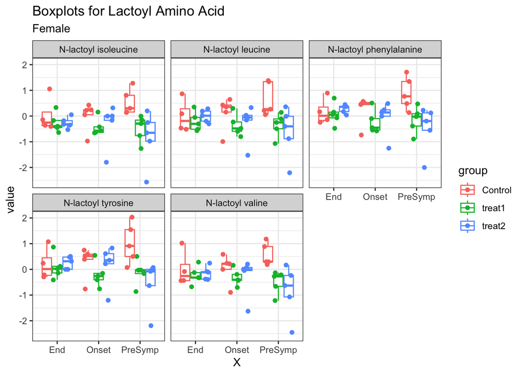

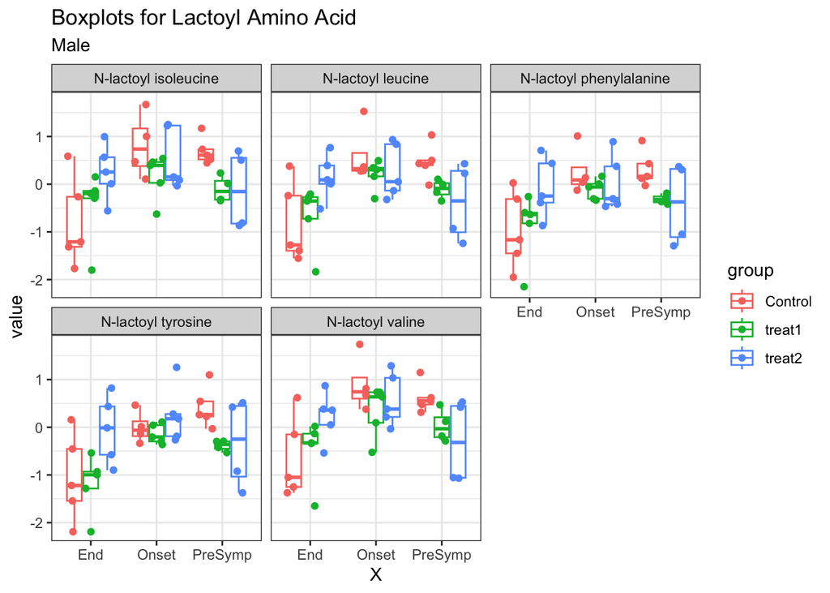

```r
dat <- params$dat

# Get the selected values from the inputs
  subpathway_var <- params$SUB_PATHWAY
  subpathway_subpath <- params$subpathway_subpath
  subpathway_treat <- params$subpathway_treat
  subpathway_block <- params$subpathway_block
  subpathway_chemName <- params$CHEMICAL_NAME
  subpathway_filter <- params$subpathway_filter


  # Create the boxplot
  if(subpathway_filter == "None"){

      subpathway_boxplots(dat,
                    subpathway = subpathway_subpath,
                    block_var = !!sym(subpathway_block),
                    treat_var = !!sym(subpathway_treat),
                    Assay = "normalized",
                    CHEMICAL_NAME = subpathway_chemName,
                    SUB_PATHWAY = subpathway_var) +
      ggtitle(paste0("Boxplots for ", subpathway_subpath))
  } else{
      for (strata in unique(dat[[subpathway_filter]])) {

        d_filtered <- dat[,colData(dat)[[subpathway_filter]] == strata ]

        p <- subpathway_boxplots(d_filtered,
                    subpathway = subpathway_subpath,
                    block_var = !!sym(subpathway_block),
                    treat_var = !!sym(subpathway_treat),
                    Assay = "normalized",
                    CHEMICAL_NAME = subpathway_chemName,
                    SUB_PATHWAY = subpathway_var) +
      ggtitle(paste0("Boxplots for ", subpathway_subpath), subtitle = strata)

        print(p)
      }
  }
```

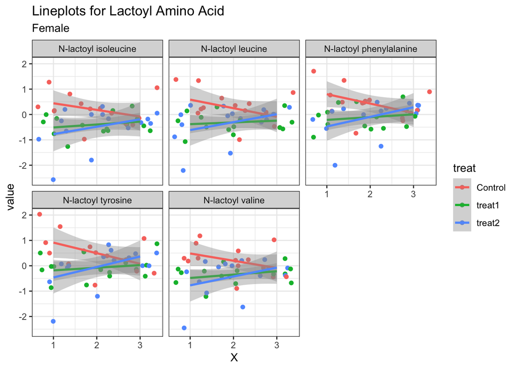

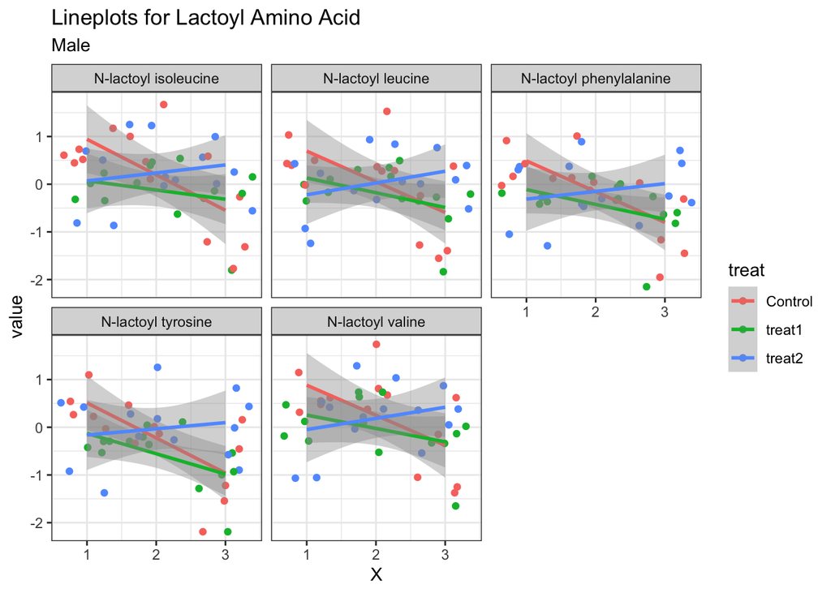

```r
# Get data
dat <- params$dat

if(params$DEMO==TRUE){

  dat$TIME1 <- as.numeric(factor(dat$TIME1,
      levels = c("PreSymp", "Onset", "End")
    ))
}

# Get the selected values from the inputs

  subpathway_var <- params$SUB_PATHWAY
  subpathway_subpath <- params$subpathway_subpath
  subpathway_treat <- params$subpathway_treat
  subpathway_block <- params$subpathway_block
  subpathway_chemName <- params$CHEMICAL_NAME
  subpathway_filter <- params$subpathway_filter

# Create line plots for the subpathway
if(subpathway_filter == "None"){

  subpathway_lineplots(dat,
                    subpathway = subpathway_subpath,
                    block_var = !!sym(subpathway_block),
                    treat_var = !!sym(subpathway_treat),
                    Assay = "normalized",
                    CHEMICAL_NAME = subpathway_chemName,
                    SUB_PATHWAY = subpathway_var) +
  ggtitle(paste0("Lineplots for ", subpathway_subpath))
} else{
  for (strata in unique(dat[[subpathway_filter]])) {

    d_filtered <- dat[,colData(dat)[[subpathway_filter]] == strata ]

    p <- subpathway_lineplots(d_filtered,
                    subpathway = subpathway_subpath,
                    block_var = !!sym(subpathway_block),
                    treat_var = !!sym(subpathway_treat),
                    Assay = "normalized",
                    CHEMICAL_NAME = subpathway_chemName,
                    SUB_PATHWAY = subpathway_var) +
      ggtitle(paste0("Lineplots for ", subpathway_subpath), subtitle = strata)

    print(p)
  }
}
```